# Project 1: Wrangling, Exploration, Visualization

SDS322E

## Data Wrangling, Exploration, Visualization

### Vanessa Zavala, vz988

#### Introduction

```r
library(tidyverse)
TeenPregnancy <- read_csv("TeenPregnancy.csv")
CrimeRates <- read_csv("af_crime93.csv")
```

The two data sets that are used in this project were acquired through the ‘Stat2Data’ package in R. The teen pregnancy data set has 50 observations, one for each state, with 5 different variables. However, one of them is redundant because it numbers the states, although that is already done by R. The other 4 variables include the ID variable that will be used to join the two data sets, which are the state abbreviations, ‘CivilWar’ which indicates how the state participated in the civil war, ‘Church’ which is the number of girls who went to church that week, and ‘Teen’ which indicates the number of teens that were pregnant per 1000 girls in that state. These values were obtained by the Guttmacher Institute on May 4, 2014 by Tanya Lewis. The second data set shows the statewide crime data for all 50 states and the District of Columbia; the data set contains 51 observations of 9 variables. The first variable is just numbering the states while the second is the ID variable, the state abbreviations. ‘Violent’ is the violent crime rate (per 100,000 people in the population), ‘murder’ is the murder rate per 100,000 people, ‘poverty’ is the percent of the population with income below the poverty level, ‘single’ is the rate of households that are led by single parents, ‘metro’ is the percent of population that live in metropolitan areas, ‘white’ is the percentage of white individuals in the state, and ‘highschool’ is the percentage of the state that graduated from high school. These two data sets were chosen because they all have interesting variables that have a possible strong correlation with one another. With states that have a higher crime rate and lower high school graduation percentage, the rate for teen pregnancy might be higher. It would also be interesting to see how the participation in the civil war might affect the teen pregnancy rate or crime rate of that specific state.

#### Tidying: Reshaping

```r
TeenPregnancy <- TeenPregnancy %>% pivot_longer(4:5, names_to = "Church/Teen",
    values_to = "Rates") %>% pivot_wider(names_from = "Church/Teen",
    values_from = "Rates") %>% select(-1)

CrimeRates <- CrimeRates %>% pivot_longer(3:9, names_to = "Data",
    values_to = "Values") %>% pivot_wider(names_from = "Data",
    values_from = "Values") %>% select(-1)
```

Because both data sets were both tidy, I made sure to pivot both of them longer followed by pivoting them wider to show that I can use the functions. I also removed the first column because it was redundant since R numbers the rows as well.

#### Joining/Merging

```r
nrow(TeenPregnancy)
```

```
## [1] 50
```

```r
ncol(TeenPregnancy)
```

```
## [1] 4
```

```r
nrow(CrimeRates)
```

```
## [1] 51
```

```r
ncol(CrimeRates)
```

```
## [1] 8
```

```r
CrimeRates %>% left_join(TeenPregnancy, by = c(state = "State"))
```

```
## # A tibble: 51 x 11
##    state violent murder poverty single metro white highschool CivilWar Church
##    <chr>   <dbl>  <dbl>   <dbl>  <dbl> <dbl> <dbl>      <dbl> <chr>     <dbl>
##  1 AK        761   9       9.10   14.3  41.8  75.2       86.6 O            26
##  2 AL        780  11.6    17.4    11.5  67.4  73.5       66.9 C            46
##  3 AR        593  10.2    20      10.7  44.7  82.9       66.3 C            45
##  4 AZ        715   8.60   15.4    12.1  84.7  88.6       78.7 O            33
##  5 CA       1078  13.1    18.2    12.5  96.7  79.3       76.2 U            28
##  6 CO        567   5.80    9.90   12.1  81.8  92.5       84.4 O            25
##  7 CT        456   6.30    8.5    10.1  95.7  89         79.2 U            25
##  8 DE        686   5      10.2    11.4  82.7  79.4       77.5 U            35
##  9 FL       1206   8.90   17.8    10.6  93    83.5       74.4 C            32
## 10 GA        723  11.4    13.5    13    67.7  70.8       70.9 C            39
## # … with 41 more rows, and 1 more variable: Teen <dbl>
```

```r
CrimeRates %>% anti_join(TeenPregnancy, by = c(state = "State"))
```

```
## # A tibble: 1 x 8
##   state violent murder poverty single metro white highschool
##   <chr>   <dbl>  <dbl>   <dbl>  <dbl> <dbl> <dbl>      <dbl>
## 1 DC       2922   78.5    26.4   22.1   100  31.8       73.1
```

```r
CrimeRates %>% semi_join(TeenPregnancy, by = c(state = "State"))
```

```
## # A tibble: 50 x 8
##    state violent murder poverty single metro white highschool
##    <chr>   <dbl>  <dbl>   <dbl>  <dbl> <dbl> <dbl>      <dbl>
##  1 AK        761   9       9.10   14.3  41.8  75.2       86.6
##  2 AL        780  11.6    17.4    11.5  67.4  73.5       66.9
##  3 AR        593  10.2    20      10.7  44.7  82.9       66.3
##  4 AZ        715   8.60   15.4    12.1  84.7  88.6       78.7
##  5 CA       1078  13.1    18.2    12.5  96.7  79.3       76.2
##  6 CO        567   5.80    9.90   12.1  81.8  92.5       84.4
##  7 CT        456   6.30    8.5    10.1  95.7  89         79.2
##  8 DE        686   5      10.2    11.4  82.7  79.4       77.5
##  9 FL       1206   8.90   17.8    10.6  93    83.5       74.4
## 10 GA        723  11.4    13.5    13    67.7  70.8       70.9
## # … with 40 more rows
```

```r
MergedData <- TeenPregnancy %>% left_join(CrimeRates, by = c(State = "state"))
```

A left join dplyr function was used to merge the data because the ‘Teen Pregnancy’ data set had all the observations the ‘CrimeRates’ data set had except one. The observations that mattered most were ones that represented each state, and because the District of Columbia is not a state, that observation was lost. However, with this loss of data, we cannot assume that any of the data within this merged data set can be applied to the District of Columbia because it is not a state nor is it located in one. After the join was done, the new data set, now called ‘MergedData’, has 50 observations of 11 variables. This is similar in number to the observations in the ‘TeenPregnancy’ data set but one less observation than ‘CrimeRates’. Before the join, the ‘TeenPregnancy’ data set had a total of 50 observations of 4 variables, with 3 of those being unique to this data set (‘CivilWar’, ‘Church’, and ‘Teen’). The ‘CrimeRates’ data set had a total of 51 observations of 8 variables, with 7 of them being unique to this data set (‘violent’, ‘murder’, ‘poverty’, ‘single’, ‘white’, ‘metro’, and ‘highschool’). The only ID variable that was found in both data sets were the 50 states of the United States.

#### Wrangling

```r
MergedData %>% group_by(CivilWar) %>% summarize(Mean.Murder.Rate = mean(murder)) %>%
    arrange(desc(Mean.Murder.Rate)) %>% mutate(CivilWar = str_replace(CivilWar,
    "Confederate", "Confederate")) %>% mutate(CivilWar = str_replace(CivilWar,
    "Other", "Other")) %>% mutate(CivilWar = str_replace(CivilWar,
    "Union", "Union")) %>% mutate(CivilWar = str_replace(CivilWar,
    "Border", "Border"))
```

```
## # A tibble: 4 x 2
##   CivilWar Mean.Murder.Rate
##   <chr>               <dbl>
## 1 C                   11.6
## 2 B                    8.77
## 3 U                    6.35
## 4 O                    5.27
```

```r
MergedData <- MergedData %>% mutate(CivilWar = str_replace(CivilWar,
    "[C]", "Confederate")) %>% mutate(CivilWar = str_replace(CivilWar,
    "[O]", "Other")) %>% mutate(CivilWar = str_replace(CivilWar,
    "[U]", "Union")) %>% mutate(CivilWar = str_replace(CivilWar,
    "[B]", "Border"))

MergedData %>% filter(poverty > 10 & highschool < 70) %>% summarize(Mean_TeenPreg = mean(Teen),
    StDev = sd(Teen), Max = max(Teen), Min = min(Teen))
```

```
## # A tibble: 1 x 4
##   Mean_TeenPreg StDev   Max   Min
##           <dbl> <dbl> <dbl> <dbl>
## 1          66.6  5.45    76    62
```

```r
MergedData %>% filter(poverty < 15 & highschool > 70) %>% summarize(Mean_TeenPreg = mean(Teen),
    StDev = sd(Teen), Max = max(Teen), Min = min(Teen))
```

```
## # A tibble: 1 x 4
##   Mean_TeenPreg StDev   Max   Min
##           <dbl> <dbl> <dbl> <dbl>
## 1          49.2  9.81    68    28
```

```r
MergedData %>% summarize(Quantiles = quantile(Teen, probs = seq(0,
    1, 1/4)))
```

```
## # A tibble: 5 x 1
##   Quantiles
##       <dbl>
## 1      28
## 2      47
## 3      54
## 4      63.8
## 5      80
```

```r
MergedData <- MergedData %>% mutate(TeenPregLevel = ifelse(Teen >
    63.75, "high", ifelse(Teen <= 63.75 & 47 <= Teen, "med",
    "low")))
head(MergedData)
```

```
## # A tibble: 6 x 12
##   State CivilWar Church  Teen violent murder poverty single metro white
##   <chr> <chr>     <dbl> <dbl>   <dbl>  <dbl>   <dbl>  <dbl> <dbl> <dbl>
## 1 AK    Other        26    64     761   9       9.10   14.3  41.8  75.2
## 2 AL    Confede…     46    62     780  11.6    17.4    11.5  67.4  73.5
## 3 AR    Confede…     45    73     593  10.2    20      10.7  44.7  82.9
## 4 AZ    Other        33    60     715   8.60   15.4    12.1  84.7  88.6
## 5 CA    Union        28    59    1078  13.1    18.2    12.5  96.7  79.3
## 6 CO    Other        25    50     567   5.80    9.90   12.1  81.8  92.5
## # … with 2 more variables: highschool <dbl>, TeenPregLevel <chr>
```

```r
MergedData %>% group_by(CivilWar, TeenPregLevel) %>% summarize(Mean.Poverty = mean(poverty)) %>%
    arrange(desc(Mean.Poverty))
```

```
## # A tibble: 10 x 3
## # Groups:   CivilWar [4]
##    CivilWar    TeenPregLevel Mean.Poverty
##    <chr>       <chr>                <dbl>
##  1 Confederate high                  20.1
##  2 Border      high                  19.9
##  3 Border      med                   18.2
##  4 Confederate med                   15.8
##  5 Union       med                   13.4
##  6 Other       high                  13.3
##  7 Other       med                   13.3
##  8 Other       low                   10.7
##  9 Union       low                   10.6
## 10 Union       high                  10.2
```

```r
MergedData %>% group_by(CivilWar) %>% summarize(count = n()) %>%
    arrange(count)
```

```
## # A tibble: 4 x 2
##   CivilWar    count
##   <chr>       <int>
## 1 Border          3
## 2 Confederate    11
## 3 Other          15
## 4 Union          21
```

```r
MergedData %>% group_by(TeenPregLevel) %>% summarize(count = n()) %>%
    arrange(count)
```

```
## # A tibble: 3 x 2
##   TeenPregLevel count
##   <chr>         <int>
## 1 low              12
## 2 high             13
## 3 med              25
```

```r
library(knitr)
Range <- function(x) max(x) - min(x)
MergedData %>% group_by(TeenPregLevel) %>% select(-1, -2) %>%
    summarize_all(c(Mean = mean, Max = max, Min = min, Range = Range)) %>%
    pivot_longer(2:37) %>% separate(name, into = c("Variables",
    "type")) %>% pivot_wider(names_from = "type", values_from = "value") %>%
    kable(digits = 3, align = "clcccc", col.names = str_to_title(names(.)))
```

| Teenpreglevel | Variables | Mean | Max | Min | Range |
| --- | --- | --- | --- | --- | --- |
| high | Church | 36.923 | 47.0 | 25.0 | 22.0 |
| high | Teen | 69.000 | 80.0 | 64.0 | 16.0 |
| high | violent | 688.692 | 1062.0 | 208.0 | 854.0 |
| high | murder | 9.931 | 20.3 | 3.8 | 16.5 |
| high | poverty | 16.715 | 26.4 | 8.0 | 18.4 |
| high | single | 12.223 | 14.9 | 9.1 | 5.8 |
| high | metro | 62.592 | 84.8 | 30.7 | 54.1 |
| high | white | 75.808 | 96.3 | 40.9 | 55.4 |
| high | highschool | 72.992 | 86.6 | 64.3 | 22.3 |
| low | Church | 28.500 | 51.0 | 17.0 | 34.0 |
| low | Teen | 39.500 | 44.0 | 28.0 | 16.0 |
| low | violent | 306.667 | 805.0 | 82.0 | 723.0 |
| low | murder | 3.342 | 6.3 | 1.6 | 4.7 |
| low | poverty | 10.642 | 12.6 | 8.5 | 4.1 |
| low | single | 9.975 | 11.0 | 8.4 | 2.6 |
| low | metro | 63.208 | 96.2 | 27.0 | 69.2 |
| low | white | 94.467 | 98.5 | 89.0 | 9.5 |
| low | highschool | 79.808 | 85.1 | 72.0 | 13.1 |
| med | Church | 32.360 | 46.0 | 24.0 | 22.0 |
| med | Teen | 54.560 | 63.0 | 47.0 | 16.0 |
| med | violent | 628.000 | 1206.0 | 178.0 | 1028.0 |
| med | murder | 7.896 | 13.3 | 2.9 | 10.4 |
| med | poverty | 14.232 | 20.4 | 9.7 | 10.7 |
| med | single | 11.076 | 13.0 | 9.4 | 3.6 |
| med | metro | 70.588 | 100.0 | 24.0 | 76.0 |
| med | white | 85.544 | 96.7 | 68.9 | 27.8 |
| med | highschool | 76.308 | 84.4 | 64.6 | 19.8 |

To find the summary statistics of all the variables within the merged data set, I first grouped by the teen pregnancy level then got rid of the first two columns which consisted of the state names and civil war participation. Then I used summarize_all to get the summary statistics needed, however, by doing this, it made the data set extremely untidy. To fix this problem, I used pivot_longer and pivot_wider to tidy up the data set which resulted in the last table presented above. An interesting finding that I was able to obtain using the first line of code above was that states that were grouped by the civil war participation of ‘Confederate’ had a larger average of murder rate as compared to the states that fell within the groups of border, union, or other. This was really interesting to look at because it was also found that states that were grouped as confederate also tended to have a higher average of teen pregnancy which leads to think about what could be causing these states to have such drastic differences compared to other states.

#### Visualizing

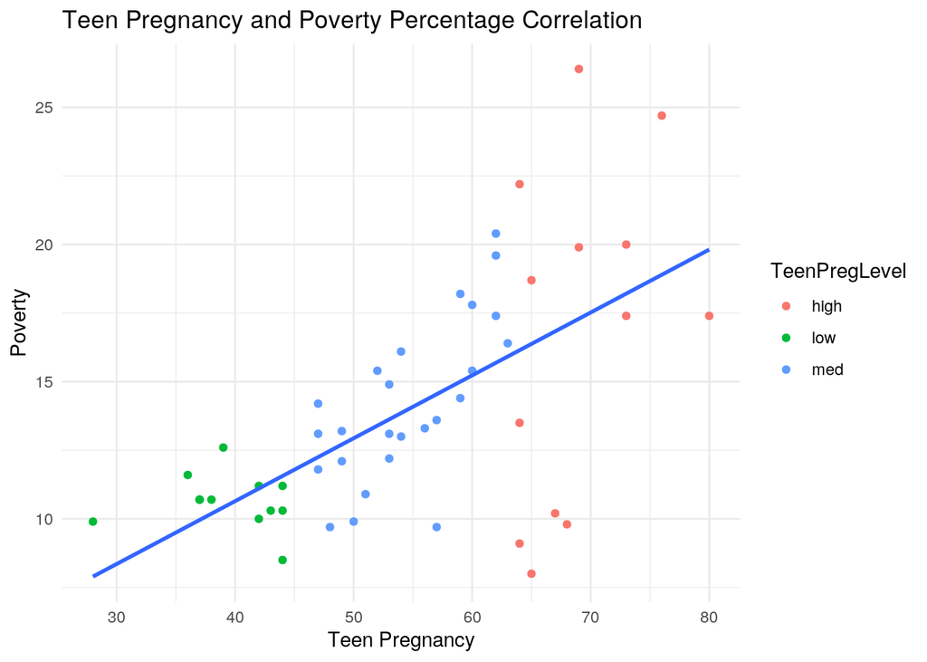

```r
ggplot(MergedData, aes(Teen, poverty)) + geom_point(aes(color = TeenPregLevel)) +
    geom_smooth(method = "lm", se = F) + theme_minimal() + ggtitle("Teen Pregnancy and Poverty Percentage Correlation") +
    ylab("Poverty") + xlab("Teen Pregnancy")
```

In the plot above, teen pregnancy and poverty were plotted within a scatter plot to show the correlation between the two. From the plot, it is evident that there is a positive correlation between teen pregnancy and poverty. As you can see, as teen pregnancy increases, the percentage of those with incomes below the poverty level increases as well. This could mean that in areas with higher teen pregnancy rates, there could be less funding towards sex education programs within the community.

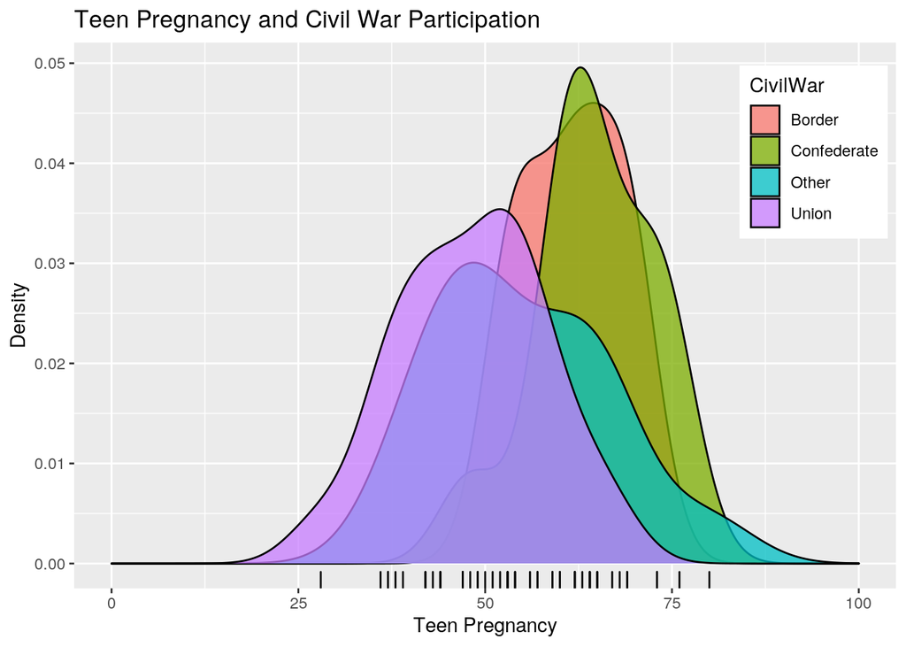

```r
ggplot(MergedData, aes(x = Teen, fill = CivilWar)) + geom_density(alpha = 0.75) +
    theme(legend.position = c(0.9, 0.8)) + geom_rug() + ggtitle("Teen Pregnancy and Civil War Participation") +
    ylab("Density") + xlab("Teen Pregnancy") + xlim(0, 100)
```

In this plot, a density plot was used to depict the relationship between teen pregnancy and civil war participation. As shown in the graph, there is a slightly higher amount of teen pregnancy in states that were on the confederate side as compared to states that were considered as other. The states known as other are states that were likely annexed or founded after the events of the Civil War. States that participated in the civil war as confederates have a higher rate of teen pregnancy, which could be due to the conservative views that have continued in the South or just a lack of funding for proper sex education.

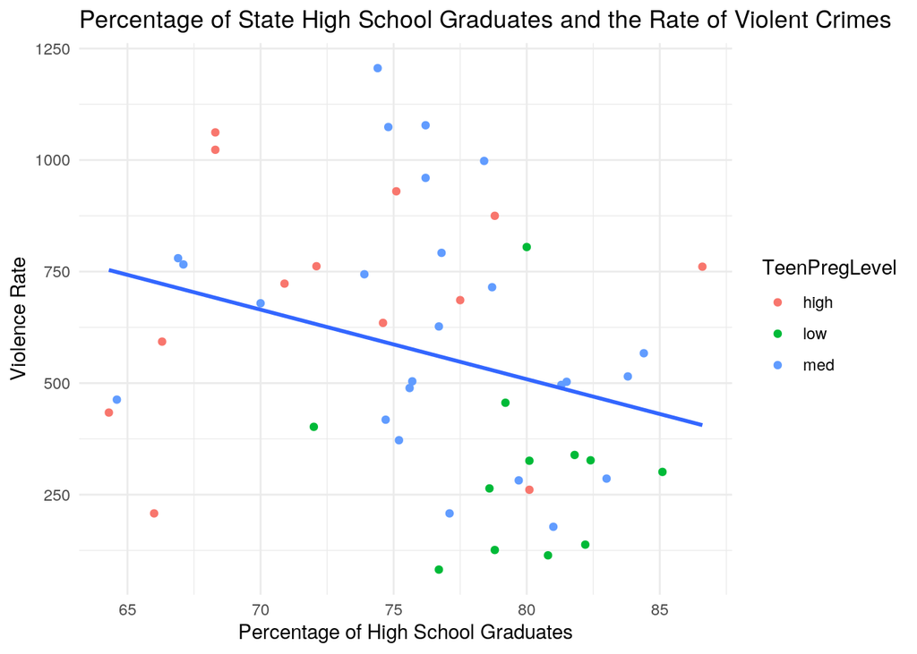

```r
ggplot(MergedData, aes(highschool, violent)) + geom_point(aes(color = TeenPregLevel)) +
    geom_smooth(method = "lm", se = F) + theme_minimal() + ggtitle("Percentage of State High School Graduates and the Rate of Violent Crimes") +
    ylab("Violence Rate") + xlab("Percentage of High School Graduates")
```